# Dataproject Analysis of surface tempertaure of earth

**Source For Data set** : https://www.kaggle.com/datasets/berkeleyearth/climate-change-earth-surface-temperature-data  
The raw data comes from the Berkeley Earth data page.

### GlobalLandTemperature in Country

1 to know the avg temperature for different countries by a period of [25years]  
2.which country has highest mean temperature till last  
3.which country has lowest mean temperature till last  
4.In a country to know the mean temperatures by months (mean of months in every year)

### Global Average Land Temperature by Cities

```python
import pandas as pd
import numpy as np
import datetime as date
import matplotlib.pyplot as plt
%matplotlib inline
import seaborn as sns
sns.set_style('whitegrid')
```

## Part 1

```python
#Global Average Land Temperature by Country (GlobalLandTemperaturesByCountry.csv)
avglantempcon=pd.read_csv(r"C:\Users\Umesh Potha\Desktop\climatedataglobal\GlobalLandTemperaturesByCountry.csv")
```

```python
avglantempcon.info()
```

```
<class 'pandas.core.frame.DataFrame'>
RangeIndex: 577462 entries, 0 to 577461
Data columns (total 4 columns):
 #   Column                         Non-Null Count   Dtype
---  ------                         --------------   -----
 0   dt                             577462 non-null  object
 1   AverageTemperature             544811 non-null  float64
 2   AverageTemperatureUncertainty  545550 non-null  float64
 3   Country                        577462 non-null  object
dtypes: float64(2), object(2)
memory usage: 17.6+ MB
```

```python
avglantempcon.head()
```

|  | dt | AverageTemperature | AverageTemperatureUncertainty | Country |
| --- | --- | --- | --- | --- |
| 0 | 1743-11-01 | 4.384 | 2.294 | Åland |
| 1 | 1743-12-01 | NaN | NaN | Åland |
| 2 | 1744-01-01 | NaN | NaN | Åland |
| 3 | 1744-02-01 | NaN | NaN | Åland |
| 4 | 1744-03-01 | NaN | NaN | Åland |

for easy in through time series we convert the strings of dt column to datetime time type using the inbuilt to _datetime method()

```python
avglantempcon['dt']=pd.to_datetime(avglantempcon['dt'])
```

```python
avglantempcon=avglantempcon[avglantempcon['dt']>='1850-01-01']
```

```python
avglantempcon.head()
```

|  | dt | AverageTemperature | AverageTemperatureUncertainty | Country |
| --- | --- | --- | --- | --- |
| 1274 | 1850-01-01 | -9.083 | 1.834 | Åland |
| 1275 | 1850-02-01 | -2.309 | 1.603 | Åland |
| 1276 | 1850-03-01 | -4.801 | 3.033 | Åland |
| 1277 | 1850-04-01 | 1.242 | 2.008 | Åland |
| 1278 | 1850-05-01 | 7.920 | 0.881 | Åland |

we skip the null values in our dataset as droping them may lead time series breakdown

lets find avg temp of whole country by years

```python
ser1=avglantempcon['Country'].unique()
```

```python
avglantempcon['year'] = avglantempcon['dt'].dt.year
```

```python
avglantempcon['month'] = avglantempcon['dt'].dt.month
```

```python
grouped=avglantempcon.groupby('year')['AverageTemperature']
```

```python
avgmean=grouped.mean()
```

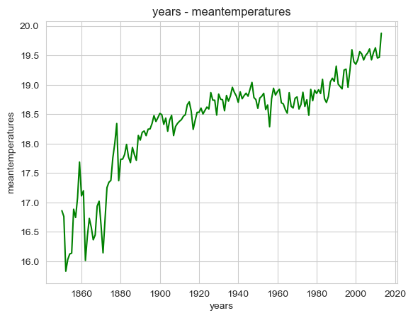

```python
plt.ylabel('meantemperatures')
plt.xlabel('years')
plt.title('years - meantemperatures')
plt.plot(avgmean,color='green')
```

```python
grouped1=avglantempcon.groupby('Country')['AverageTemperature']
```

```python
avgtempcon=grouped1.mean()
```

```python
lst=list(avgtempcon.index)
```

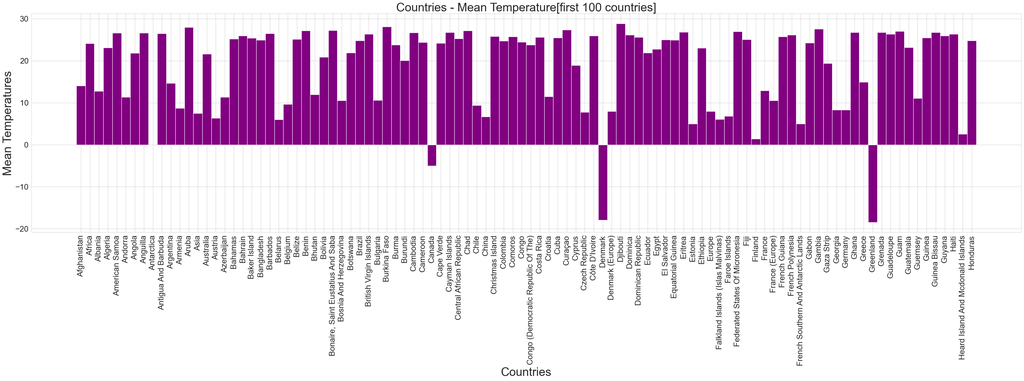

```python
plt.figure(figsize=(45,10))
plt.bar(lst[0:100],avgtempcon[0:100],color='purple',width=1)
_=plt.xticks(rotation=90,fontsize=20)
_=plt.yticks(fontsize=20)
_=plt.xlabel('Countries',fontsize=30)
_=plt.ylabel('Mean Temperatures',fontsize=30)
_=plt.title('Countries - Mean Temperature[first 100 countries]',fontsize=30)
```

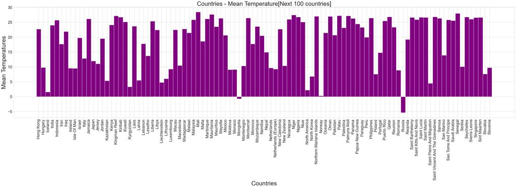

```python
plt.figure(figsize=(45,10))
plt.bar(lst[100:200],avgtempcon[100:200],color='purple',width=1)
_=plt.xticks(rotation=90,fontsize=20)
_=plt.yticks(fontsize=20)
_=plt.xlabel('Countries',fontsize=30)
_=plt.ylabel('Mean Temperatures',fontsize=30)
_=plt.title('Countries - Mean Temperature[Next 100 countries]',fontsize=30)
```

```python
grouped2 = avglantempcon.groupby(['year', 'Country'])['AverageTemperature']
```

```python
avg_mean_by_year_country =grouped2.mean()
```

```python
dataset=avg_mean_by_year_country.unstack()
```

```python
dataset
```

| Country year | Afghanistan | Africa | Albania | Algeria | American Samoa | Andorra | Angola | Anguilla | Antarctica | Antigua And Barbuda | ... | Uruguay | Uzbekistan | Venezuela | Vietnam | Virgin Islands | Western Sahara | Yemen | Zambia | Zimbabwe | Åland |
| --- | --- | --- | --- | --- | --- | --- | --- | --- | --- | --- | --- | --- | --- | --- | --- | --- | --- | --- | --- | --- | --- |
| 1850 | 13.326083 | 23.672273 | 11.734667 | 22.587333 | NaN | 10.651750 | NaN | 26.106333 | NaN | 25.933250 | ... | NaN | 11.618333 | 24.539167 | 23.198417 | 25.855667 | 22.182250 | NaN | 20.423182 | 20.154364 | 4.648667 |
| 1851 | 13.605667 | NaN | 12.315500 | 22.733333 | NaN | 10.297083 | NaN | 26.261250 | NaN | 26.060917 | ... | 16.840417 | 12.042750 | 24.605250 | 23.352583 | 26.006333 | 22.487000 | NaN | NaN | NaN | 5.306333 |
| 1852 | 13.541167 | NaN | 12.744583 | 22.856583 | NaN | 11.503750 | NaN | 26.026000 | NaN | 25.855167 | ... | 16.806167 | 11.875833 | 24.491583 | 23.219333 | 25.738167 | 22.128000 | NaN | NaN | NaN | 4.995667 |
| 1853 | 13.455833 | NaN | 12.811167 | 22.770583 | NaN | 10.111333 | NaN | 26.241500 | NaN | 26.076583 | ... | 16.780000 | 11.667750 | 24.623083 | 23.504250 | 25.973833 | 21.986333 | NaN | NaN | NaN | 4.907750 |
| 1854 | 13.605750 | NaN | 11.951667 | 22.481167 | NaN | 10.682417 | NaN | 26.165333 | NaN | 25.983583 | ... | 16.951833 | 12.074583 | 24.572583 | 23.497250 | 25.890167 | 22.003667 | NaN | NaN | NaN | 5.626667 |
| ... | ... | ... | ... | ... | ... | ... | ... | ... | ... | ... | ... | ... | ... | ... | ... | ... | ... | ... | ... | ... | ... |
| 2009 | 15.257750 | 25.026500 | 13.844250 | 24.154333 | 27.034250 | 12.566667 | 22.316500 | 27.468583 | NaN | 27.277333 | ... | 17.871333 | 13.700333 | 26.084917 | 24.465583 | 27.238500 | 23.381083 | 27.342417 | 21.670250 | 21.377250 | 6.489083 |
| 2010 | 15.828667 | 25.472500 | 13.775417 | 25.215667 | 27.453417 | 11.480833 | 22.681500 | 27.856000 | NaN | 27.735417 | ... | 17.920083 | 14.325917 | 26.150250 | 24.833333 | 27.593667 | 24.114250 | 27.302750 | 22.267500 | 21.986250 | 4.861917 |
| 2011 | 15.518000 | 24.786500 | 13.443250 | 24.144167 | 27.009500 | 12.994417 | 22.029667 | 27.528333 | NaN | 27.296167 | ... | 17.824583 | 13.141083 | 25.677333 | 23.692583 | 27.159250 | 23.401250 | 27.288250 | 21.771583 | 21.602417 | 7.170750 |
| 2012 | 14.481583 | 24.725917 | 13.768250 | 23.954833 | 27.201417 | 12.339917 | 22.123333 | 27.639250 | NaN | 27.433500 | ... | 18.509000 | 13.144167 | 25.688583 | 24.704333 | 27.360167 | 23.303417 | 27.445000 | 21.697750 | 21.521333 | 6.063917 |
| 2013 | 16.533625 | 25.208750 | 14.993875 | 25.121500 | 27.517250 | 12.307875 | 22.507875 | 27.363000 | NaN | 27.249625 | ... | 16.754375 | 16.188250 | 25.912875 | 25.232125 | 27.312333 | 23.744250 | 28.129750 | 21.196000 | 20.710750 | 6.229750 |

164 rows × 243 columns

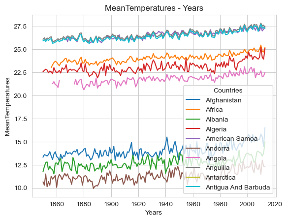

```python
for x in dataset.columns[0:10]:
    plt.plot(dataset.index,dataset[x],label=x)
plt.title('MeanTemperatures - Years')
plt.ylabel('MeanTemperatures')
plt.xlabel('Years')
plt.legend(loc='best',title="Countries")
```

[output not shown]

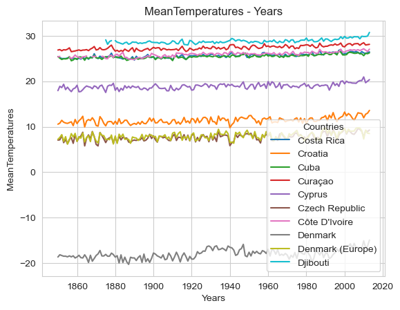

```python
plt.title('MeanTemperatures - Years')
plt.ylabel('MeanTemperatures')
plt.xlabel('Years')
plt.legend(loc='best')
for x in dataset.columns[51:61]:
    plt.plot(dataset.index,dataset[x],label=x)
plt.legend(loc='best',title='Countries')
```

```python
month_names = {
    1: 'January',
    2: 'February',
    3: 'March',
    4: 'April',
    5: 'May',
    6: 'June',
    7: 'July',
    8: 'August',
    9: 'September',
    10: 'October',
    11: 'November',
    12: 'December'
}

avglantempcon['month'] = avglantempcon['month'].map(month_names)
```

```python
grouped3=avglantempcon.groupby('month')['AverageTemperature']
avgmeanmonth=grouped3.mean()
```

```python
avgmeanmonth=avgmeanmonth.reindex(['January', 'February', 'March', 'April', 'May', 'June', 'July', 'August', 'September', 'October', 'November', 'December'])
```

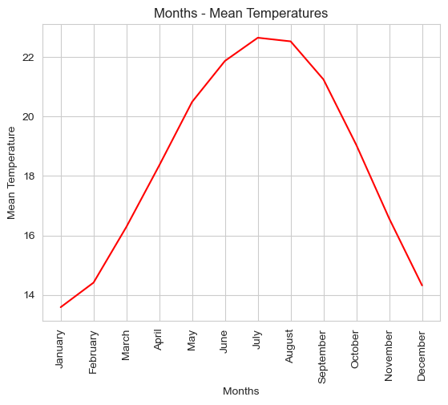

```python
plt.title('Months - Mean Temperatures')
plt.xlabel('Months')
plt.ylabel('Mean Temperature')
_=plt.xticks(rotation=90)
plt.plot(avgmeanmonth,color='red')
plt.show()
```

```python
grouped4 = avglantempcon.groupby(['month', 'Country'])['AverageTemperature']
```

```python
avgmeantempmon=grouped4.mean()
```

```python
dataset2=avgmeantempmon.unstack()
```

```python
dataset2=dataset2.reindex(['January', 'February', 'March', 'April', 'May', 'June', 'July', 'August', 'September', 'October', 'November', 'December'])
```

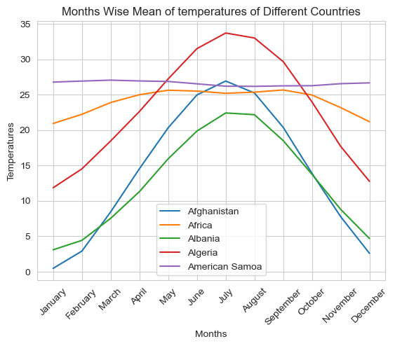

```python
plt.xlabel('Months')
plt.ylabel('Temperatures')
plt.title('Months Wise Mean of temperatures of Different Countries')
for x in dataset2.columns[0:5]:
    plt.plot(dataset2.index,dataset2[x],label=x)
_=plt.xticks(rotation=45)
plt.legend()
```

## Part 2

```python
#to know the avg temperature for different states by a period of [25years]
```

```python
climate=pd.read_csv(r"C:\Users\Umesh Potha\Desktop\climatedataglobal\GlobalLandTemperaturesByMajorCity.csv")
```

```python
city=(climate[climate['City'].isin(['Delhi','Bombay','Madras','Bangalore','Calcutta'])])
city.head()
```

|  | dt | AverageTemperature | AverageTemperatureUncertainty | City | Country | Latitude | Longitude |
| --- | --- | --- | --- | --- | --- | --- | --- |
| 17335 | 1796-01-01 | 22.672 | 2.317 | Bangalore | India | 12.05N | 77.26E |
| 17336 | 1796-02-01 | 24.420 | 1.419 | Bangalore | India | 12.05N | 77.26E |
| 17337 | 1796-03-01 | 26.092 | 2.459 | Bangalore | India | 12.05N | 77.26E |
| 17338 | 1796-04-01 | 27.687 | 1.746 | Bangalore | India | 12.05N | 77.26E |
| 17339 | 1796-05-01 | 27.619 | 1.277 | Bangalore | India | 12.05N | 77.26E |

```python
city=city[city['dt']>'1988-01-01']
```

```python
city['dt']=pd.to_datetime(city['dt'])
```

```python
city['year']=city['dt'].dt.year
```

```python
group1=city.groupby(['year','City'])['AverageTemperature']
```

```python
data=group1.mean().unstack()
data.head()
```

| City year | Bangalore | Bombay | Calcutta | Delhi | Madras |
| --- | --- | --- | --- | --- | --- |
| 1988 | 25.717909 | 27.477636 | 27.550364 | 27.020182 | 29.414182 |
| 1989 | 25.198417 | 26.913083 | 26.494583 | 25.432583 | 28.668583 |
| 1990 | 25.254833 | 26.975250 | 26.362417 | 25.538250 | 28.764833 |
| 1991 | 25.487083 | 26.961167 | 26.541833 | 25.738667 | 28.833583 |
| 1992 | 25.159250 | 27.074417 | 26.412667 | 25.521083 | 28.660833 |

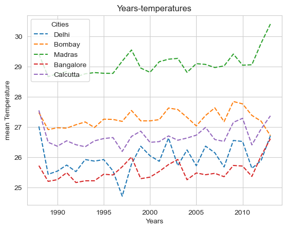

```python
plt.xlabel('Years')
plt.ylabel('mean Temperature')
plt.title('Years-temperatures')
for i in ['Delhi','Bombay','Madras','Bangalore','Calcutta']:
    plt.plot(data[i],label=i,linestyle='--')
plt.legend(loc='upper left',title='Cities')
```

```python
filtered_df = climate[climate['Country'].isin(['India'])]
```

```python
city_mean_temperatures = filtered_df.groupby('City')['AverageTemperature'].mean().reset_index()

highest_temp_city = city_mean_temperatures.loc[city_mean_temperatures['AverageTemperature'].idxmax()]
lowest_temp_city = city_mean_temperatures.loc[city_mean_temperatures['AverageTemperature'].idxmin()]
city_mean_temperatures
```

|  | City | AverageTemperature |
| --- | --- | --- |
| 0 | Ahmadabad | 26.529853 |
| 1 | Bangalore | 24.855896 |
| 2 | Bombay | 26.631452 |
| 3 | Calcutta | 26.042152 |
| 4 | Delhi | 25.165861 |
| 5 | Hyderabad | 26.869335 |
| 6 | Jaipur | 25.393058 |
| 7 | Kanpur | 24.760041 |
| 8 | Lakhnau | 24.760041 |
| 9 | Madras | 28.417858 |
| 10 | Nagpur | 25.655016 |
| 11 | New Delhi | 25.165861 |
| 12 | Pune | 24.644615 |
| 13 | Surat | 26.330856 |

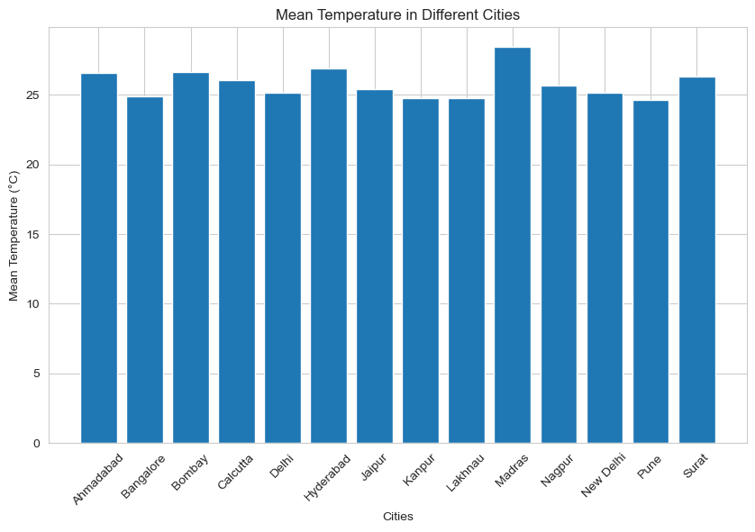

[output not shown]

```python
plt.figure(figsize=(10, 6))
plt.bar(city_mean_temperatures['City'], city_mean_temperatures['AverageTemperature'])
plt.xlabel('Cities')
plt.ylabel('Mean Temperature (°C)')
plt.title('Mean Temperature in Different Cities')
plt.xticks(rotation=45)
plt.show()

print(f"The city with the lowest mean temperature among the specified cities is {highest_temp_city['City']} with an average temperature of {highest_temp_city['AverageTemperature']:.2f} °C.")
print(f"The city with the lowest mean temperature among the specified cities is {lowest_temp_city['City']} with an average temperature of {lowest_temp_city['AverageTemperature']:.2f} °C.")
```

```python
climate['dt']=pd.to_datetime(climate['dt'])
climate['month'] = climate['dt'].dt.month
month_names = {
    1: 'January',
    2: 'February',
    3: 'March',
    4: 'April',
    5: 'May',
    6: 'June',
    7: 'July',
    8: 'August',
    9: 'September',
    10: 'October',
    11: 'November',
    12: 'December'
}

climate['month'] = climate['month'].map(month_names)
```

```python
climate
```

|  | dt | AverageTemperature | AverageTemperatureUncertainty | City | Country | Latitude | Longitude | month |
| --- | --- | --- | --- | --- | --- | --- | --- | --- |
| 0 | 1849-01-01 | 26.704 | 1.435 | Abidjan | Côte D'Ivoire | 5.63N | 3.23W | January |
| 1 | 1849-02-01 | 27.434 | 1.362 | Abidjan | Côte D'Ivoire | 5.63N | 3.23W | February |
| 2 | 1849-03-01 | 28.101 | 1.612 | Abidjan | Côte D'Ivoire | 5.63N | 3.23W | March |
| 3 | 1849-04-01 | 26.140 | 1.387 | Abidjan | Côte D'Ivoire | 5.63N | 3.23W | April |
| 4 | 1849-05-01 | 25.427 | 1.200 | Abidjan | Côte D'Ivoire | 5.63N | 3.23W | May |
| ... | ... | ... | ... | ... | ... | ... | ... | ... |
| 239172 | 2013-05-01 | 18.979 | 0.807 | Xian | China | 34.56N | 108.97E | May |
| 239173 | 2013-06-01 | 23.522 | 0.647 | Xian | China | 34.56N | 108.97E | June |
| 239174 | 2013-07-01 | 25.251 | 1.042 | Xian | China | 34.56N | 108.97E | July |
| 239175 | 2013-08-01 | 24.528 | 0.840 | Xian | China | 34.56N | 108.97E | August |
| 239176 | 2013-09-01 | NaN | NaN | Xian | China | 34.56N | 108.97E | September |

239177 rows × 8 columns

```python
filteredf1 = climate[climate['Country'].isin(['India'])]
```

```python
grouped1 = filteredf1.groupby(['City','month'])['AverageTemperature']
avgmeantempmon=grouped1.mean()
dataset3=avgmeantempmon.unstack()
dataset3=dataset3.reindex(columns=['January', 'February', 'March', 'April', 'May', 'June', 'July', 'August', 'September', 'October', 'November', 'December'])
```

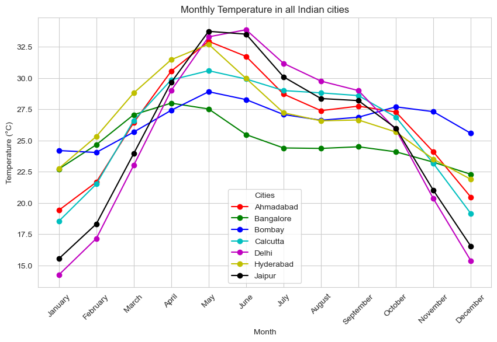

```python
import matplotlib.pyplot as plt

plt.figure(figsize=(10, 6))
plt.title('Monthly Temperature in all Indian cities')
plt.xlabel('Month')
plt.ylabel('Temperature (°C)')
plt.xticks(rotation=45)
plt.grid(True)

cities = ["Ahmadabad", "Bangalore", "Bombay", "Calcutta", "Delhi", "Hyderabad", "Jaipur"]
colors = ['r', 'g', 'b', 'c', 'm', 'y', 'k']

for city, color in zip(cities, colors):
    plt.plot(dataset3.loc[city], marker='o', linestyle='-', label=city, color=color)

plt.legend(loc='lower center',title='Cities')
plt.show()
```

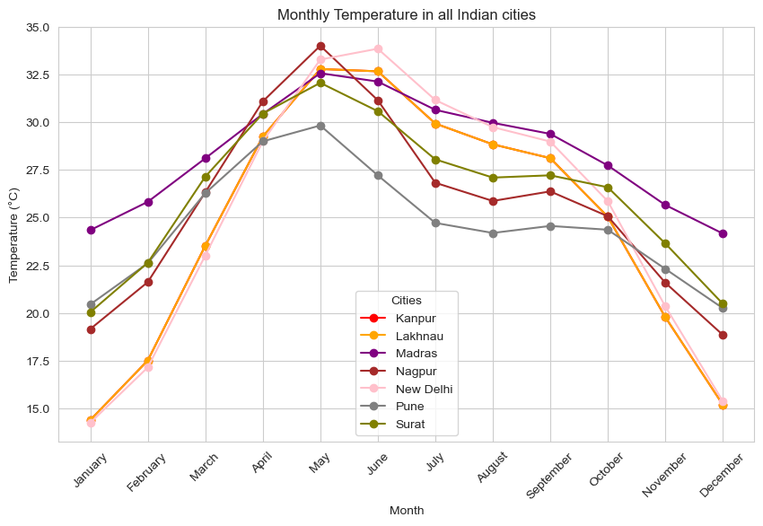

```python
plt.figure(figsize=(10, 6))
plt.title('Monthly Temperature in all Indian cities')
plt.xlabel('Month')
plt.ylabel('Temperature (°C)')
plt.xticks(rotation=45)
plt.grid(True)

colors = ['red', 'orange', 'purple', 'brown', 'pink', 'gray', 'olive']
cities = ["Kanpur", "Lakhnau", "Madras", "Nagpur", "New Delhi", "Pune", "Surat"]

for city, color in zip(cities, colors):
    plt.plot(dataset3.loc[city], marker='o', linestyle='-', label=city, color=color)


plt.legend(loc='lower center',title='Cities')
plt.show()
```

```python
grouped5 =filteredf1["AverageTemperature"].groupby(filteredf1["Latitude"])
avgmeantemp=grouped5.mean()
```

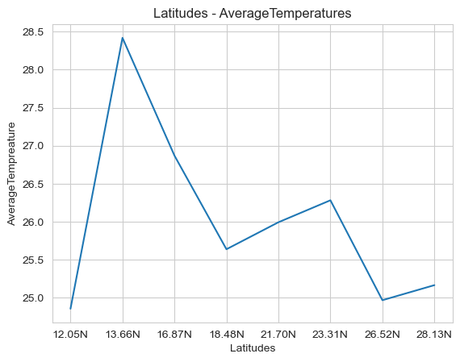

```python
plt.ylabel('AverageTempreature')
plt.xlabel('Latitudes')
plt.title('Latitudes - AverageTemperatures')
plt.plot(avgmeantemp)
```

There are many factors for surface temperatures so we cannot define just by latitudes so there is an irregularity in the plot which is observed